# Pertemuan-3

## Model Autoregressive

Peubah dependen dipengaruhi oleh peubah independen pada waktu sekarang, serta dipengaruhi juga oleh peubah dependen itu sendiri pada satu waktu yang lalu maka model tersebut disebut *autoregressive* (Gujarati 2004).

### Pemodelan

Pemodelan Autoregressive dilakukan menggunakan fungsi `dLagM::ardlDlm()` . Fungsi tersebut akan menerapkan *autoregressive* berordo $(p,q)$ dengan satu prediktor. Fungsi umum dari `ardlDlm()` adalah sebagai berikut.

```r
ardlDlm(formula = NULL , data = NULL , x = NULL , y = NULL , p = 1 , q = 1 ,
         remove = NULL )
```

Dengan $p$ adalah integer yang mewakili panjang *lag* yang terbatas dan $q$ adalah integer yang merepresentasikan ordo dari proses *autoregressive*.

```r
# Membuat model ARDL (Autoregressive Distributed Lag)

# ardlDlm() digunakan untuk membentuk model ARDL,
# yaitu model regresi dinamis yang mengkombinasikan lag dari variabel dependen (p) dan lag dari variabel independen (q).
model.ardl <- ardlDlm(x = train$Xt, y = train$Yt, p = 1, q = 1)

# Menampilkan ringkasan hasil estimasi model (koefisien, signifikansi, dll.)
summary(model.ardl)
```

```
##
## Time series regression with "ts" data:
## Start = 2, End = 65
##
## Call:
## dynlm(formula = as.formula(model.text), data = data, start = 1)
##
## Residuals:
##     Min      1Q  Median      3Q     Max
## -2.2063 -0.5584  0.1424  0.5977  1.8329
##
## Coefficients:
##             Estimate Std. Error t value Pr(>|t|)
## (Intercept) -7.56138    7.43205  -1.017 0.313047
## X.t          0.25441    0.06834   3.723 0.000437 ***
## X.1         -0.20214    0.06697  -3.018 0.003728 **
## Y.1          0.88483    0.06220  14.226  < 2e-16 ***
## ---
## Signif. codes:  0 '***' 0.001 '**' 0.01 '*' 0.05 '.' 0.1 ' ' 1
##
## Residual standard error: 0.8781 on 60 degrees of freedom
## Multiple R-squared:  0.9181, Adjusted R-squared:  0.914
## F-statistic: 224.1 on 3 and 60 DF,  p-value: < 2.2e-16
```

```r
# Menghitung nilai AIC (Akaike Information Criterion) untuk mengevaluasi kualitas model
# Nilai AIC yang lebih kecil → model lebih baik
AIC(model.ardl)
```

```
## [1] 170.8603
```

```r
# Menghitung nilai BIC (Bayesian Information Criterion)
# Sama seperti AIC, nilai BIC lebih kecil = model lebih baik
BIC(model.ardl)
```

```
## [1] 181.6547
```

```r
model.ardl <- ardlDlm(formula = Yt ~ Xt, data = train, p = 1, q = 1)

# Menampilkan ringkasan hasil estimasi (koefisien, uji signifikansi, dll.)
summary(model.ardl)
```

```
##
## Time series regression with "ts" data:
## Start = 2, End = 65
##
## Call:
## dynlm(formula = as.formula(model.text), data = data)
##
## Residuals:
##     Min      1Q  Median      3Q     Max
## -2.2063 -0.5584  0.1424  0.5977  1.8329
##
## Coefficients:
##             Estimate Std. Error t value Pr(>|t|)
## (Intercept) -7.56138    7.43205  -1.017 0.313047
## Xt.t         0.25441    0.06834   3.723 0.000437 ***
## Xt.1        -0.20214    0.06697  -3.018 0.003728 **
## Yt.1         0.88483    0.06220  14.226  < 2e-16 ***
## ---
## Signif. codes:  0 '***' 0.001 '**' 0.01 '*' 0.05 '.' 0.1 ' ' 1
##
## Residual standard error: 0.8781 on 60 degrees of freedom
## Multiple R-squared:  0.9181, Adjusted R-squared:  0.914
## F-statistic: 224.1 on 3 and 60 DF,  p-value: < 2.2e-16
```

```r
# Menghitung nilai Akaike Information Criterion (AIC)
# → digunakan untuk membandingkan model, semakin kecil nilainya semakin baik
AIC(model.ardl)
```

```
## [1] 170.8603
```

```r
# Menghitung nilai Bayesian Information Criterion (BIC)
# juga dipakai untuk seleksi model, lebih ketat dibanding AIC
BIC(model.ardl)
```

```
## [1] 181.6547
```

Hasil di atas menunjukkan bahwa peubah$x_{t}$, $x_{t-1}$, dan $y_{t-1}$ berpengaruh signifikan terhadap. Model keseluruhannya adalah sebagai berikut:

$$\hat{Y}=-7.56138+0.25441X_t-0.20214X_{t-1}+0.88483Y_{t-1}$$

### Peramalan dan Akurasi

```r
# h = 7 => jumlah periode ke depan yang akan diramalkan (7 periode)
fore.ardl <- forecast(model = model.ardl, x = test$Xt, h = 7)

# Menampilkan hasil ramalan
fore.ardl
```

```
## $forecasts
## [1] 21.05313 21.10014 21.56633 22.06608 22.59552 23.15122 23.30557
##
## $call
## forecast.ardlDlm(model = model.ardl, x = test$Xt, h = 7)
##
## attr(,"class")
## [1] "forecast.ardlDlm" "dLagM"
```

Data di atas merupakan hasil peramalan untuk 7 periode ke depan menggunakan Model Autoregressive dengan $p=1$ dan $q=1$.

```r
# Mengukur akurasi model ARDL pada data test
mape.ardl <- MAPE(fore.ardl$forecasts, test$Yt)
mape.ardl   # nilai MAPE pada data test
```

```
## [1] 0.07839114
```

```r
# Akurasi pada data training
GoF(model.ardl)
```

```
##             n       MAE          MPE       MAPE      sMAPE      MASE      MSE
## model.ardl 64 0.6807527 -0.001077334 0.02630302 0.02621706 0.9927643 0.722936
##                  MRAE    GMRAE
## model.ardl 1399932113 5926.647
```

Berdasarkan akurasi di atas model regresi dengan distribusi lag ini tidak `overfitted` atau `underfitted`

### *Lag* Optimum

```r
# Penentuan lag optimum ARDL dengan kriteria AIC

# Mencari kombinasi lag p (Yt) dan q (Xt) yang optimal berdasarkan nilai AIC terkecil.

model.ardl.opt <- ardlBoundOrders(data = data.frame(data), ic = "AIC",
                                  formula = Yt ~ Xt)
model.ardl.opt   # Menampilkan hasil tabel AIC untuk berbagai kombinasi p dan q
```

```
## $p
##   Xt
## 1 15
##
## $q
## [1] 6
##
## $Stat.table
##           q = 1    q = 2    q = 3    q = 4    q = 5    q = 6    q = 7    q = 8
## p = 1  168.2819 166.2651 161.6607 157.9799 154.9460 151.9007 142.2749 141.7655
## p = 2  164.8473 163.3331 156.4568 151.0675 150.6558 148.6743 140.6526 141.4722
## p = 3  160.5057 160.5057 158.4568 152.1418 151.9442 149.7779 142.4972 143.2945
## p = 4  155.5034 157.0582 157.0582 153.7779 152.8901 150.8933 144.4972 145.2908
## p = 5  146.4334 147.6417 148.8275 148.8275 146.8885 146.7953 144.1138 145.0288
## p = 6  139.0372 140.7460 142.7230 143.5938 143.5938 144.1934 138.5749 137.9094
## p = 7  140.9979 142.8013 142.6491 141.1302 139.4065 139.4065 140.1131 137.9821
## p = 8  138.7038 138.4923 138.9648 135.5878 135.4907 137.0041 137.0041 138.2546
## p = 9  131.1103 131.5073 133.4716 131.8017 133.3762 134.6431 136.6223 136.6223
## p = 10 127.4866 128.4487 130.4390 130.6004 132.5984 131.8950 133.7767 135.0119
## p = 11 127.6469 128.5046 130.5013 129.8532 131.7773 128.1875 129.6869 131.2037
## p = 12 127.6711 127.4897 129.1757 129.1393 130.9412 129.2049 130.5135 132.0888
## p = 13 127.1372 127.2852 129.1244 129.2587 131.2254 129.8983 131.5868 132.7144
## p = 14 124.1624 124.8474 126.6710 124.1665 124.7897 122.6937 123.9309 125.4630
## p = 15 122.7462 123.0762 124.8446 122.7514 122.5267 121.7055 122.6973 124.5513
##           q = 9   q = 10   q = 11   q = 12   q = 13   q = 14   q = 15
## p = 1  137.6136 134.5537 134.3595 133.8624 132.4862 126.1388 127.1749
## p = 2  137.6932 136.3732 136.0768 135.3172 133.9918 127.5516 128.6567
## p = 3  139.6931 138.3709 138.0742 137.1511 135.7321 129.0672 130.0955
## p = 4  141.6927 140.2948 140.0211 139.0491 137.5738 130.4145 131.5771
## p = 5  140.0291 138.2008 139.4185 138.7488 135.7582 124.1257 125.3936
## p = 6  136.3957 135.9295 137.1350 136.3849 132.5901 124.2831 125.9430
## p = 7  137.6802 137.6837 138.8278 138.0075 134.3664 126.0066 127.6530
## p = 8  136.6303 134.5083 135.7606 135.3003 132.2279 124.6417 126.0605
## p = 9  138.5702 136.4569 137.7360 137.2816 134.2170 126.5949 127.6740
## p = 10 135.0119 137.0097 138.4844 138.7962 136.1884 128.5944 129.6737
## p = 11 133.1740 133.1740 135.0144 136.6470 134.3021 127.3736 128.3392
## p = 12 133.9481 135.9389 135.9389 137.9254 133.5946 129.1369 130.0157
## p = 13 134.6415 136.5655 138.5652 138.5652 133.3119 130.4395 131.3026
## p = 14 127.4116 128.9961 130.2393 130.0985 130.0985 131.9376 133.1505
## p = 15 126.2884 128.2638 128.8698 129.5035 131.1930 131.1930 133.1899
##
## $min.Stat
## [1] 121.7055
```

```r
# Menentukan p dan q optimum secara manual

# Buat vektor kosong untuk menyimpan nilai minimum AIC setiap q
min_p = c()

# Loop untuk mencari nilai AIC minimum pada setiap q
for(i in 1:10){
  min_p[i] = min(model.ardl.opt$Stat.table[[i]])
}

# Menentukan nilai q optimum (lag Xt) → posisi AIC terkecil
q_opt = which(min_p == min(min_p, na.rm = TRUE))

# Menentukan nilai p optimum (lag Yt) → posisi AIC terkecil pada q tersebut
p_opt = which(model.ardl.opt$Stat.table[[q_opt]] ==
                min(model.ardl.opt$Stat.table[[q_opt]], na.rm = TRUE))

# Menyusun hasil akhir dalam bentuk data frame
data.frame("q_optimum" = q_opt,
           "p_optimum" = p_opt,
           "AIC" = model.ardl.opt$min.Stat)
```

```
##   q_optimum p_optimum      AIC
## 1         6        15 121.7055
```

Dari tabel di atas, dapat terlihat bahwa nilai AIC terendah didapat ketika $p=15$ dan $q=6$, yaitu sebesar `121.7055`. Artinya, model autoregressive optimum didapat ketika $p=15$ dan $q=6$.

```r
# p = 15 => jumlah lag untuk variabel dependen Yt (autoregressive order)
# q = 6  => jumlah lag untuk variabel independen Xt (distributed lag order)
model.ardl.opt <- ardlDlm(x = train$Xt, y = train$Yt, p = 15, q = 6)

# Menampilkan ringkasan hasil estimasi:
# berisi koefisien model, uji signifikansi parameter, R-squared, dll.
summary(model.ardl.opt)
```

```
##
## Time series regression with "ts" data:
## Start = 16, End = 65
##
## Call:
## dynlm(formula = as.formula(model.text), data = data, start = 1)
##
## Residuals:
##      Min       1Q   Median       3Q      Max
## -0.99320 -0.25470 -0.02517  0.25072  1.16113
##
## Coefficients:
##              Estimate Std. Error t value Pr(>|t|)
## (Intercept) -32.96440   17.69843  -1.863   0.0734 .
## X.t           0.11697    0.09599   1.219   0.2336
## X.1           0.09110    0.12416   0.734   0.4694
## X.2          -0.20199    0.12174  -1.659   0.1087
## X.3           0.09514    0.12838   0.741   0.4651
## X.4          -0.04116    0.12831  -0.321   0.7509
## X.5          -0.21515    0.13411  -1.604   0.1203
## X.6           0.46605    0.14110   3.303   0.0027 **
## X.7          -0.07222    0.16475  -0.438   0.6646
## X.8          -0.18821    0.15629  -1.204   0.2390
## X.9           0.18676    0.15906   1.174   0.2506
## X.10          0.02895    0.16167   0.179   0.8592
## X.11         -0.09024    0.14818  -0.609   0.5476
## X.12         -0.03577    0.14034  -0.255   0.8007
## X.13          0.02833    0.12708   0.223   0.8253
## X.14          0.09415    0.12565   0.749   0.4602
## X.15         -0.05102    0.07714  -0.661   0.5140
## Y.1           0.98575    0.19807   4.977 3.24e-05 ***
## Y.2           0.13636    0.26320   0.518   0.6086
## Y.3          -0.09583    0.25998  -0.369   0.7153
## Y.4           0.02601    0.26624   0.098   0.9229
## Y.5          -0.30189    0.25796  -1.170   0.2521
## Y.6          -0.10632    0.19712  -0.539   0.5941
## ---
## Signif. codes:  0 '***' 0.001 '**' 0.01 '*' 0.05 '.' 0.1 ' ' 1
##
## Residual standard error: 0.5814 on 27 degrees of freedom
## Multiple R-squared:  0.9825, Adjusted R-squared:  0.9682
## F-statistic: 68.72 on 22 and 27 DF,  p-value: < 2.2e-16
```

```r
# Menghitung nilai Akaike Information Criterion (AIC)
# → digunakan untuk mengevaluasi kualitas model, semakin kecil semakin baik
AIC(model.ardl.opt)
```

```
## [1] 104.8514
```

```r
# Menghitung nilai Bayesian Information Criterion (BIC)
# → kriteria evaluasi lain, lebih ketat daripada AIC
BIC(model.ardl.opt)
```

```
## [1] 150.74
```

```r
model.ardl.opt <- ardlDlm(formula = Yt ~ Xt,
                         data = train,p = 15 , q = 6)
summary(model.ardl.opt)
```

```
##
## Time series regression with "ts" data:
## Start = 16, End = 65
##
## Call:
## dynlm(formula = as.formula(model.text), data = data)
##
## Residuals:
##      Min       1Q   Median       3Q      Max
## -0.99320 -0.25470 -0.02517  0.25072  1.16113
##
## Coefficients:
##              Estimate Std. Error t value Pr(>|t|)
## (Intercept) -32.96440   17.69843  -1.863   0.0734 .
## Xt.t          0.11697    0.09599   1.219   0.2336
## Xt.1          0.09110    0.12416   0.734   0.4694
## Xt.2         -0.20199    0.12174  -1.659   0.1087
## Xt.3          0.09514    0.12838   0.741   0.4651
## Xt.4         -0.04116    0.12831  -0.321   0.7509
## Xt.5         -0.21515    0.13411  -1.604   0.1203
## Xt.6          0.46605    0.14110   3.303   0.0027 **
## Xt.7         -0.07222    0.16475  -0.438   0.6646
## Xt.8         -0.18821    0.15629  -1.204   0.2390
## Xt.9          0.18676    0.15906   1.174   0.2506
## Xt.10         0.02895    0.16167   0.179   0.8592
## Xt.11        -0.09024    0.14818  -0.609   0.5476
## Xt.12        -0.03577    0.14034  -0.255   0.8007
## Xt.13         0.02833    0.12708   0.223   0.8253
## Xt.14         0.09415    0.12565   0.749   0.4602
## Xt.15        -0.05102    0.07714  -0.661   0.5140
## Yt.1          0.98575    0.19807   4.977 3.24e-05 ***
## Yt.2          0.13636    0.26320   0.518   0.6086
## Yt.3         -0.09583    0.25998  -0.369   0.7153
## Yt.4          0.02601    0.26624   0.098   0.9229
## Yt.5         -0.30189    0.25796  -1.170   0.2521
## Yt.6         -0.10632    0.19712  -0.539   0.5941
## ---
## Signif. codes:  0 '***' 0.001 '**' 0.01 '*' 0.05 '.' 0.1 ' ' 1
##
## Residual standard error: 0.5814 on 27 degrees of freedom
## Multiple R-squared:  0.9825, Adjusted R-squared:  0.9682
## F-statistic: 68.72 on 22 and 27 DF,  p-value: < 2.2e-16
```

```r
AIC(model.ardl.opt)
```

```
## [1] 104.8514
```

```r
BIC(model.ardl.opt)
```

```
## [1] 150.74
```

### Peramalan dan Akurasi Lag Opt

```r
# Peramalan (Forecast) dengan model ARDL lag optimum
fore.ardl.opt <- forecast(model = model.ardl.opt, x = test$Xt, h = 7)

# Menampilkan hasil ramalan
fore.ardl.opt
```

```
## $forecasts
## [1] 21.43458 23.28561 24.89266 26.05062 27.30030 28.56484 29.23640
##
## $call
## forecast.ardlDlm(model = model.ardl.opt, x = test$Xt, h = 7)
##
## attr(,"class")
## [1] "forecast.ardlDlm" "dLagM"
```

```r
# Menghitung nilai akurasi peramalan pada data test
mape.ardl.opt <- MAPE(fore.ardl.opt$forecasts, test$Yt)
mape.ardl.opt
```

```
## [1] 0.07122648
```

```r
# Menghitung akurasi model pada data training
GoF(model.ardl.opt)
```

```
##                 n       MAE           MPE       MAPE      sMAPE      MASE
## model.ardl.opt 50 0.3432839 -0.0002784487 0.01293786 0.01293707 0.5606971
##                      MSE       MRAE    GMRAE
## model.ardl.opt 0.1825286 1428187403 7332.146
```

## Pemodelan DLM & ARDL dengan Library `dynlm`

Pemodelan regresi dengan peubah *lag* tidak hanya dapat dilakukan dengan fungsi pada *packages* `dLagM` , tetapi terdapat *packages* `dynlm` yang dapat digunakan. Fungsi `dynlm` secara umum adalah sebagai berikut.

```r
dynlm(formula, data, subset, weights, na.action, method = "qr",
  model = TRUE, x = FALSE, y = FALSE, qr = TRUE, singular.ok = TRUE,
  contrasts = NULL, offset, start = NULL, end = NULL, ...)
```

Untuk menentukan `formula` model yang akan digunakan, tersedia fungsi tambahan yang memungkinkan spesifikasi dinamika (melalui `d()` dan `L()`) atau pola linier/siklus dengan mudah (melalui `trend()`, `season()`, dan `harmon()`). Semua fungsi formula baru mengharuskan argumennya berupa objek deret waktu (yaitu, `"ts"` atau `"zoo"`).

`L()` : fungsi untuk mengambil nilai lag dari suatu variabel.

`L(Xt)`= Xt pada periode sebelumnya (lag ke-1).

`L(Xt, 2)` = Xt pada dua periode sebelumnya (lag ke-2).

```r
#sama dengan model dlm q=1
cons_lm1 <- dynlm(Yt ~ Xt+L(Xt),data = train.ts)

#sama dengan model ardl p=1 q=0
cons_lm2 <- dynlm(Yt ~ Xt+L(Yt),data = train.ts)

#sama dengan ardl p=1 q=1
cons_lm3 <- dynlm(Yt ~ Xt+L(Xt)+L(Yt),data = train.ts)

#sama dengan dlm p=2
cons_lm4 <- dynlm(Yt ~ Xt+L(Xt)+L(Xt,2),data = train.ts)
```

### Ringkasan Model

Berikut adalah ringkasan hasil estimasi dari masing-masing model:

```r
summary(cons_lm1)
```

```
##
## Time series regression with "ts" data:
## Start = 2, End = 65
##
## Call:
## dynlm(formula = Yt ~ Xt + L(Xt), data = train.ts)
##
## Residuals:
##     Min      1Q  Median      3Q     Max
## -4.8244 -0.7716  0.2812  1.1421  3.5520
##
## Coefficients:
##              Estimate Std. Error t value Pr(>|t|)
## (Intercept) -82.19590   10.91721  -7.529 2.85e-10 ***
## Xt            0.59115    0.13295   4.446 3.76e-05 ***
## L(Xt)        -0.05019    0.13711  -0.366    0.716
## ---
## Signif. codes:  0 '***' 0.001 '**' 0.01 '*' 0.05 '.' 0.1 ' ' 1
##
## Residual standard error: 1.821 on 61 degrees of freedom
## Multiple R-squared:  0.6418, Adjusted R-squared:   0.63
## F-statistic: 54.64 on 2 and 61 DF,  p-value: 2.524e-14
```

```r
summary(cons_lm2)
```

```
##
## Time series regression with "ts" data:
## Start = 2, End = 65
##
## Call:
## dynlm(formula = Yt ~ Xt + L(Yt), data = train.ts)
##
## Residuals:
##     Min      1Q  Median      3Q     Max
## -2.3443 -0.7381  0.1718  0.5146  2.0911
##
## Coefficients:
##              Estimate Std. Error t value Pr(>|t|)
## (Intercept) -14.39878    7.53428  -1.911   0.0607 .
## Xt            0.09020    0.04401   2.049   0.0447 *
## L(Yt)         0.85489    0.06536  13.080   <2e-16 ***
## ---
## Signif. codes:  0 '***' 0.001 '**' 0.01 '*' 0.05 '.' 0.1 ' ' 1
##
## Residual standard error: 0.9347 on 61 degrees of freedom
## Multiple R-squared:  0.9056, Adjusted R-squared:  0.9025
## F-statistic: 292.7 on 2 and 61 DF,  p-value: < 2.2e-16
```

```r
summary(cons_lm3)
```

```
##
## Time series regression with "ts" data:
## Start = 2, End = 65
##
## Call:
## dynlm(formula = Yt ~ Xt + L(Xt) + L(Yt), data = train.ts)
##
## Residuals:
##     Min      1Q  Median      3Q     Max
## -2.2063 -0.5584  0.1424  0.5977  1.8329
##
## Coefficients:
##             Estimate Std. Error t value Pr(>|t|)
## (Intercept) -7.56138    7.43205  -1.017 0.313047
## Xt           0.25441    0.06834   3.723 0.000437 ***
## L(Xt)       -0.20214    0.06697  -3.018 0.003728 **
## L(Yt)        0.88483    0.06220  14.226  < 2e-16 ***
## ---
## Signif. codes:  0 '***' 0.001 '**' 0.01 '*' 0.05 '.' 0.1 ' ' 1
##
## Residual standard error: 0.8781 on 60 degrees of freedom
## Multiple R-squared:  0.9181, Adjusted R-squared:  0.914
## F-statistic: 224.1 on 3 and 60 DF,  p-value: < 2.2e-16
```

```r
summary(cons_lm4)
```

```
##
## Time series regression with "ts" data:
## Start = 3, End = 65
##
## Call:
## dynlm(formula = Yt ~ Xt + L(Xt) + L(Xt, 2), data = train.ts)
##
## Residuals:
##     Min      1Q  Median      3Q     Max
## -4.7879 -0.9359  0.2678  1.0674  3.2787
##
## Coefficients:
##              Estimate Std. Error t value Pr(>|t|)
## (Intercept) -86.59191   11.78807  -7.346 7.02e-10 ***
## Xt            0.66264    0.15955   4.153 0.000107 ***
## L(Xt)        -0.19363    0.26816  -0.722 0.473102
## L(Xt, 2)      0.09354    0.16466   0.568 0.572126
## ---
## Signif. codes:  0 '***' 0.001 '**' 0.01 '*' 0.05 '.' 0.1 ' ' 1
##
## Residual standard error: 1.787 on 59 degrees of freedom
## Multiple R-squared:  0.6644, Adjusted R-squared:  0.6474
## F-statistic: 38.94 on 3 and 59 DF,  p-value: 5.233e-14
```

### SSE

Selain ringkasan hasil, kita juga bisa menghitung nilai SSE dari masing-masing model.

```r
deviance(cons_lm1)
```

```
## [1] 202.3224
```

```r
deviance(cons_lm2)
```

```
## [1] 53.29312
```

```r
deviance(cons_lm3)
```

```
## [1] 46.26791
```

```r
deviance(cons_lm4)
```

```
## [1] 188.3504
```

Semakin kecil nilai SSE, berarti model lebih baik dalam menyesuaikan data (karena error lebih kecil).

### Ui encomptest

langkah selanjutnya adalah membandingkan kinerja antar model. selanjutnya adalah membandingkan kinerja antar model. Salah satu pendekatan yang dapat digunakan adalah encompassing test dengan fungsi `encomptest()` dari package `lmtest`.

```r
#uji model
if(require("lmtest")) encomptest(cons_lm1, cons_lm2)
```

```
## Encompassing test
##
## Model 1: Yt ~ Xt + L(Xt)
## Model 2: Yt ~ Xt + L(Yt)
## Model E: Yt ~ Xt + L(Xt) + L(Yt)
##           Res.Df Df        F    Pr(>F)
## M1 vs. ME     60 -1 202.3708 < 2.2e-16 ***
## M2 vs. ME     60 -1   9.1103  0.003728 **
## ---
## Signif. codes:  0 '***' 0.001 '**' 0.01 '*' 0.05 '.' 0.1 ' ' 1
```

#### Uji Autokorelasi Residual

```r
#durbin watson
dwtest(cons_lm1)
```

```
##
##  Durbin-Watson test
##
## data:  cons_lm1
## DW = 0.3626, p-value < 2.2e-16
## alternative hypothesis: true autocorrelation is greater than 0
```

```r
dwtest(cons_lm2)
```

```
##
##  Durbin-Watson test
##
## data:  cons_lm2
## DW = 0.94009, p-value = 6.788e-07
## alternative hypothesis: true autocorrelation is greater than 0
```

```r
dwtest(cons_lm3)
```

```
##
##  Durbin-Watson test
##
## data:  cons_lm3
## DW = 1.303, p-value = 0.000731
## alternative hypothesis: true autocorrelation is greater than 0
```

```r
dwtest(cons_lm4)
```

```
##
##  Durbin-Watson test
##
## data:  cons_lm4
## DW = 0.41891, p-value = 5.478e-16
## alternative hypothesis: true autocorrelation is greater than 0
```

#### Uji Heterogenitas

```r
bptest(cons_lm1)
```

```
##
##  studentized Breusch-Pagan test
##
## data:  cons_lm1
## BP = 3.7749, df = 2, p-value = 0.1515
```

```r
bptest(cons_lm2)
```

```
##
##  studentized Breusch-Pagan test
##
## data:  cons_lm2
## BP = 3.3673, df = 2, p-value = 0.1857
```

```r
bptest(cons_lm3)
```

```
##
##  studentized Breusch-Pagan test
##
## data:  cons_lm3
## BP = 1.6969, df = 3, p-value = 0.6376
```

```r
bptest(cons_lm4)
```

```
##
##  studentized Breusch-Pagan test
##
## data:  cons_lm4
## BP = 8.4158, df = 3, p-value = 0.03816
```

- Jika p-value > 0.05 → tidak ada heteroskedastisitas
- Jika p-value ≤ 0.05 → ada heteroskedastisitas.

#### Uji Normalitas

H0: Residual berdistribusi normal.

H1: Residual tidak berdistribusi normal.

```r
shapiro.test(residuals(cons_lm1))
```

```
##
##  Shapiro-Wilk normality test
##
## data:  residuals(cons_lm1)
## W = 0.93488, p-value = 0.002207
```

```r
shapiro.test(residuals(cons_lm2))
```

```
##
##  Shapiro-Wilk normality test
##
## data:  residuals(cons_lm2)
## W = 0.97475, p-value = 0.2127
```

```r
shapiro.test(residuals(cons_lm3))
```

```
##
##  Shapiro-Wilk normality test
##
## data:  residuals(cons_lm3)
## W = 0.98847, p-value = 0.8156
```

```r
shapiro.test(residuals(cons_lm4))
```

```
##
##  Shapiro-Wilk normality test
##
## data:  residuals(cons_lm4)
## W = 0.93047, p-value = 0.001545
```

- Jika p-value > 0.05 → gagal tolak H0 → residual normal.
- Jika p-value ≤ 0.05 → tolak H0 → residual tidak normal.

## Perbandingan Model

Membuat tabel ringkas akurasi model berdasarkan nilai MAPE (Mean Absolute Percentage Error).

```r
akurasi <- matrix(c(mape.koyck, mape.dlm, mape.dlm2, mape.ardl, mape.ardl.opt))
row.names(akurasi)<- c("Koyck","DLM 1","DLM 2","Autoregressive", "Autoregressive Opt Lag")
colnames(akurasi) <- c("MAPE")
akurasi
```

```
##                              MAPE
## Koyck                  0.11191327
## DLM 1                  0.04775086
## DLM 2                  0.02988708
## Autoregressive         0.07839114
## Autoregressive Opt Lag 0.07122648
```

Berdasarkan nilai MAPE, model paling optimum didapat pada Model DLM 2 karena memiliki nilai MAPE yang terkecil.

### Plot

Untuk membandingkan hasil peramalan dari berbagai model (Koyck, DLM 1, DLM 2, ARDL, dan ARDL Opt) dengan data aktual, dibuat grafik garis. Visualisasi ini membantu melihat seberapa dekat hasil ramalan tiap model dengan nilai aktual.

```r
str(test$Xt)
```

```
##  num [1:7] 192 192 194 195 197 ...
```

```r
str(test$Yt)
```

```
##  num [1:7] 21 21 22 24 26 27 28
```

```r
str(fore.koyck$forecasts)
```

```
##  num [1:7(1d)] 21.1 21.2 21.2 21.3 21.3 ...
```

```r
str(fore.dlm$forecasts)
```

```
##  num [1:7(1d)] 21.4 21.4 22.5 23.3 24.2 ...
```

```r
str(fore.dlm2$forecasts)
```

```
##  num [1:7(1d)] 20.8 21.8 23.1 24 25.3 ...
```

```r
str(fore.ardl$forecasts)
```

```
##  num [1:7(1d)] 21.1 21.1 21.6 22.1 22.6 ...
```

```r
str(fore.ardl.opt$forecasts)
```

```
##  num [1:7(1d)] 21.4 23.3 24.9 26.1 27.3 ...
```

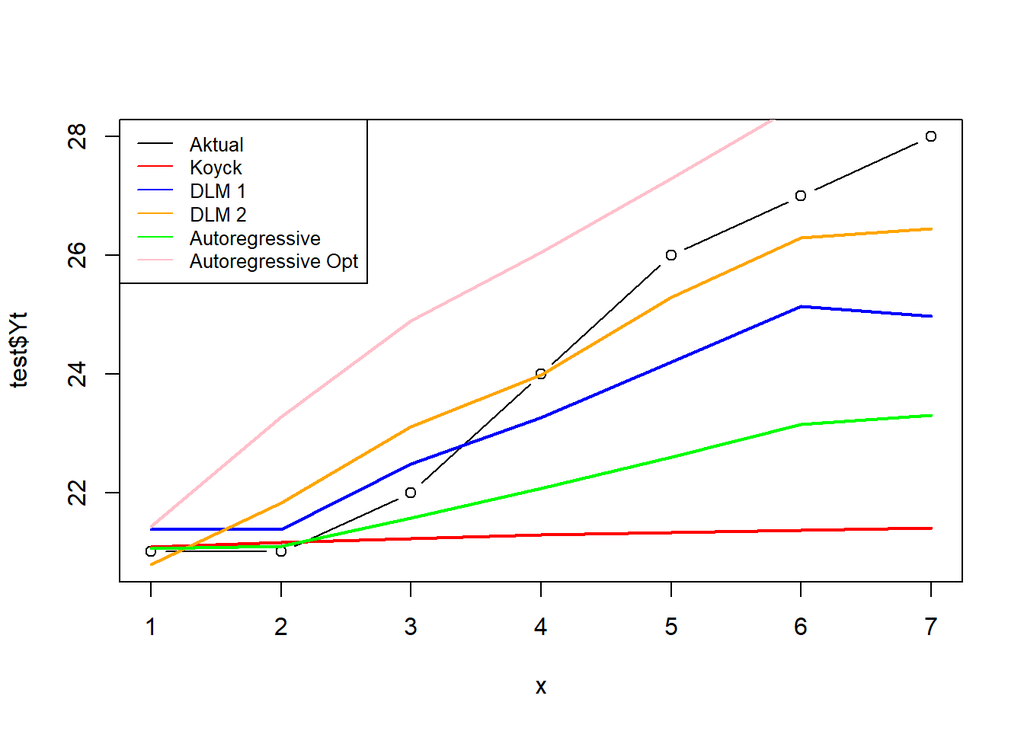

```r
x <- 1:length(test$Xt)  # buat x = 1,2,3,...,7

plot(x, test$Yt, type="b", col="black",
     ylim=range(c(test$Yt, fore.koyck$forecasts,
                  fore.dlm$forecasts, fore.dlm2$forecasts,
                  fore.ardl$forecasts)))

lines(x, fore.koyck$forecasts, col="red", lwd=2)
lines(x, fore.dlm$forecasts, col="blue", lwd=2)
lines(x, fore.dlm2$forecasts, col="orange", lwd=2)
lines(x, fore.ardl$forecasts, col="green", lwd=2)
lines(x, fore.ardl.opt$forecasts, col="pink", lwd=2)

legend("topleft",
       c("Aktual", "Koyck","DLM 1","DLM 2", "Autoregressive", "Autoregressive Opt"),
       lty=1, col=c("black","red","blue","orange","green", "pink"), cex=0.8)
```